# Sesión 3 · Muestreo e Inferencia Estadística

Fundamentos de Probabilidad y Estadística — Doctorados en Ciencias de la Complejidad Social y en Políticas Públicas · UDD

Amaru Agüero Jiménez (a.agueroj@udd.cl)

marzo de 2026

## Panorama de la sesión

| Bloque | Concepto clave | Herramienta en R |
| --- | --- | --- |
| Muestreo | Población, muestra i.i.d., $\theta$ vs $\hat{\theta}$ | `sample()` |
| Distribución muestral | $\mathbb{E}[\bar{X}] = \mu$, $\operatorname{Var}(\bar{X}) = \sigma^2/n$, TCL | `replicate()` |
| Propiedades | Insesgadez, eficiencia, consistencia | `var()`, simulación |
| Intervalos | IC 95% con $z$ y con $t$ | `t.test()`, `qt()` |
| Contraste de hipótesis | 6 pasos, valor-p, errores I y II | `t.test()` |
| Potencia | $1-\beta$ y diseño muestral | `power.t.test()` |

**La pregunta de la sesión:** observamos una muestra de $n$ unidades, pero la política pública se decide sobre la **población completa**. ¿Cómo saltamos de una a otra cuantificando la incertidumbre del salto?

## De la población a la muestra: notación formal

**Población:** modelamos la variable de interés como $X \sim F$, con parámetro desconocido $\theta \in \Theta \subseteq \mathbb{R}^k$ (fijo, no aleatorio).

**Muestra aleatoria simple:** $X_1, X_2, \dots, X_n$ son **i.i.d.** (independientes e idénticamente distribuidas):

$$X_1, \dots, X_n \overset{\text{iid}}{\sim} F \iff P(X_1 \le x_1, \dots, X_n \le x_n) = \prod_{i=1}^{n} F(x_i)$$

- **Independientes:** conocer una observación no informa sobre las demás.
- **Idénticamente distribuidas:** todas provienen de la misma $F$, con $\mathbb{E}[X_i] = \mu$ y $\operatorname{Var}(X_i) = \sigma^2$ para todo $i$.

**Ejemplo:** la encuesta CASEN selecciona hogares con probabilidades conocidas para que los ingresos muestrales se comporten (aproximadamente) como extracciones i.i.d. de la distribución de ingresos de Chile. Un muestreo por conveniencia rompe el supuesto y toda la teoría que sigue.

## Parámetro, estadístico y estimador

$$\theta = \text{parámetro (poblacional, fijo, desconocido)} \qquad \hat{\theta}_n = g(X_1, \dots, X_n) = \text{estimador}$$

Un **estadístico** es cualquier función de la muestra que **no depende de parámetros desconocidos**. Un **estimador** es el estadístico que usamos para aproximar $\theta$; su valor realizado $\hat{\theta}(x_1,\dots,x_n)$ es la **estimación**.

| Parámetro poblacional | Estimador muestral | En R |
| --- | --- | --- |
| Media $\mu = \mathbb{E}[X]$ | $\bar{X}_n = \frac{1}{n}\sum_{i=1}^n X_i$ | `mean(x)` |
| Varianza $\sigma^2 = \operatorname{Var}(X)$ | $s^2 = \frac{1}{n-1}\sum_{i=1}^n (X_i - \bar{X})^2$ | `var(x)` |
| Proporción $p$ | $\hat{p} = \frac{1}{n}\sum_{i=1}^n \mathbb{1}(X_i = 1)$ | `mean(x == 1)` |
| Correlación $\rho$ | $r$ de Pearson | `cor(x, y)` |

**Que significa esto:** la tasa de pobreza *verdadera* de una región es $\theta$; la tasa calculada con la CASEN es $\hat{\theta}_n$. Nunca son idénticas — la inferencia mide cuánto pueden diferir.

## La distribución muestral: el estimador ES una variable aleatoria

Como $\hat{\theta}_n$ es función de variables aleatorias, **es una variable aleatoria**: cambia de muestra en muestra.

$$F_{\hat{\theta}_n}(t) = P\left(\hat{\theta}_n \le t\right)$$

es su **distribución muestral**: la distribución de los valores de $\hat{\theta}_n$ bajo muestreo repetido de tamaño $n$.

- Cada encuesta distinta entrega una media distinta.
- La distribución muestral describe ese abanico de resultados posibles.
- Toda la inferencia (IC, tests) se construye sobre ella.

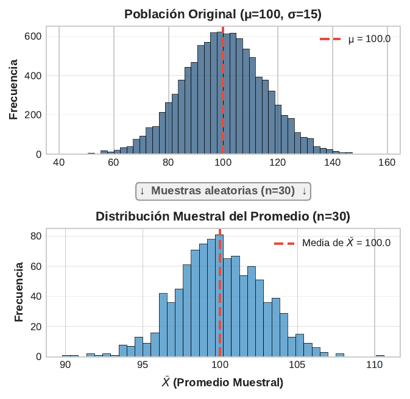

## Demostración: $\mathbb{E}[\bar{X}_n] = \mu$

Sean $X_1, \dots, X_n$ i.i.d. con $\mathbb{E}[X_i] = \mu$. Entonces:

$$\begin{aligned}
\mathbb{E}[\bar{X}_n] &= \mathbb{E}\left[\frac{1}{n}\sum_{i=1}^{n} X_i\right] \\[2pt]
&= \frac{1}{n}\,\mathbb{E}\left[\sum_{i=1}^{n} X_i\right] && \text{(la constante } 1/n \text{ sale de } \mathbb{E}) \\[2pt]
&= \frac{1}{n}\sum_{i=1}^{n} \mathbb{E}[X_i] && \text{(linealidad de la esperanza)} \\[2pt]
&= \frac{1}{n}\cdot n\mu = \mu && \text{(idéntica distribución)} \; \blacksquare
\end{aligned}$$

**Que significa esto:** el promedio muestral no apunta sistemáticamente ni por arriba ni por abajo de $\mu$. Si repitiéramos la encuesta miles de veces, el promedio de los promedios coincidiría con el parámetro. Nótese que solo usamos linealidad: **no** se necesita independencia ni normalidad.

## Demostración: $\operatorname{Var}(\bar{X}_n) = \sigma^2 / n$

Ahora sí usamos la **independencia** (las covarianzas cruzadas se anulan):

$$\begin{aligned}
\operatorname{Var}(\bar{X}_n) &= \operatorname{Var}\left(\frac{1}{n}\sum_{i=1}^{n} X_i\right) = \frac{1}{n^2}\operatorname{Var}\left(\sum_{i=1}^{n} X_i\right) && \text{(}\operatorname{Var}(cY) = c^2 \operatorname{Var}(Y)\text{)} \\
&= \frac{1}{n^2}\left[\sum_{i=1}^{n}\operatorname{Var}(X_i) + \sum_{i \ne j}\operatorname{Cov}(X_i, X_j)\right] && \text{(varianza de una suma)} \\
&= \frac{1}{n^2}\sum_{i=1}^{n}\operatorname{Var}(X_i) = \frac{n\sigma^2}{n^2} = \frac{\sigma^2}{n} && \text{(indep.} \Rightarrow \operatorname{Cov} = 0\text{)} \; \blacksquare
\end{aligned}$$

**Error estándar:** $\operatorname{SE}(\bar{X}_n) = \sigma/\sqrt{n}$, la desviación estándar de la distribución muestral de $\bar{X}_n$.

**Que significa esto:** la precisión mejora con $\sqrt{n}$, no con $n$: para **duplicar** la precisión hay que **cuadruplicar** la muestra.

## Simulación: la distribución muestral en acción

[interactive chart not shown]

Población **exponencial** (media $\mu = 5$, DE $\sigma = 5$, muy sesgada). Las medias de muestras con $n = 30$ se concentran alrededor de 5 con DE empírica $\approx 0.90$, casi idéntica al valor teórico $\sigma/\sqrt{n} = 5/\sqrt{30} \approx 0.91$ — y su forma ya es simétrica.

## Teorema Central del Límite: enunciado formal

**Teorema (Lindeberg–Lévy).** Sean $X_1, X_2, \dots$ i.i.d. con $\mathbb{E}[X_i] = \mu$ y $\operatorname{Var}(X_i) = \sigma^2 \in (0, \infty)$. Entonces

$$Z_n = \frac{\bar{X}_n - \mu}{\sigma/\sqrt{n}} \;\xrightarrow{\;d\;}\; \mathcal{N}(0, 1) \qquad (n \to \infty)$$

donde $\xrightarrow{d}$ denota **convergencia en distribución**: $\lim_{n\to\infty} P(Z_n \le z) = \Phi(z)$ para todo $z \in \mathbb{R}$.

**Hipótesis (todas necesarias):** (i) observaciones i.i.d.; (ii) media finita; (iii) **varianza finita**. No se exige normalidad ni simetría de $F$.

**Lectura en palabras:** cualquiera sea la forma de la población — ingresos sesgados, conteos, dicotómicas — la media muestral estandarizada se comporta como una normal estándar cuando $n$ es grande. En la práctica: $\bar{X}_n \overset{\text{aprox}}{\sim} \mathcal{N}(\mu, \sigma^2/n)$.

**Que significa esto:** el TCL es la licencia matemática para usar la campana de Gauss en encuestas de ingreso, pobreza o victimización, aunque ninguna de esas variables sea normal.

## TCL en acción: de una exponencial a la normal

[interactive chart not shown]

Con $n = 2$ la distribución de $\bar{X}_n$ hereda el sesgo exponencial; con $n = 30$ la curva normal (roja, con media $5$ y DE $5/\sqrt{n}$) ya calza; con $n = 100$ el ajuste es casi perfecto. La regla práctica $n \ge 30$ nace de aquí — con poblaciones muy sesgadas conviene más.

## Por qué el TCL habilita toda la inferencia

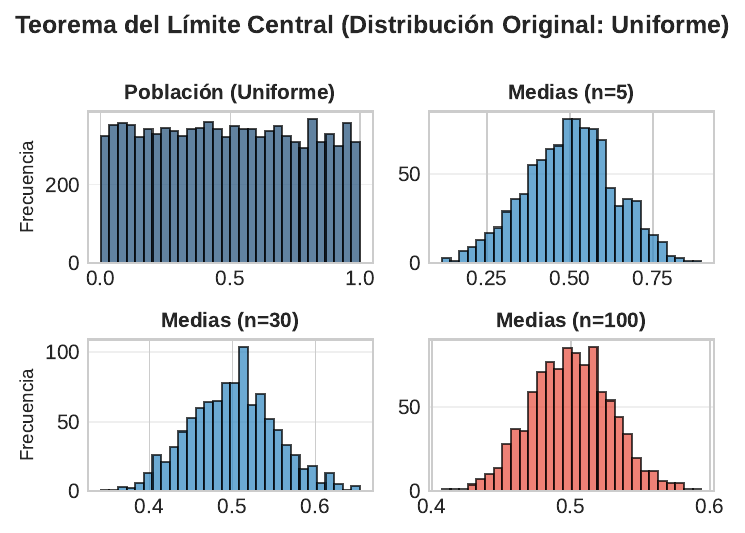

El TCL convierte un problema imposible en uno resuelto:

- **Sin TCL:** necesitaríamos conocer la distribución exacta de $\bar{X}_n$ para cada población posible.
- **Con TCL:** basta $\mu$, $\sigma$ y $n$; la forma límite es siempre la misma normal.
- Los **intervalos de confianza** y los **contrastes de hipótesis** de esta sesión descansan en esta aproximación.
- Cuando falla (colas muy pesadas con varianza infinita, dependencia fuerte, $n$ pequeño), la inferencia estándar puede ser engañosa.

## ¿Qué hace bueno a un estimador? Tres propiedades

| Propiedad | Definición formal | Pregunta que responde |
| --- | --- | --- |
| Insesgadez | $\mathbb{E}[\hat{\theta}_n] = \theta$ para todo $\theta$ | ¿Apunta al blanco en promedio? |
| Eficiencia | $\operatorname{Var}(\hat{\theta}_n) \le \operatorname{Var}(\tilde{\theta}_n)$ entre insesgados | ¿Es el de menor dispersión? |
| Consistencia | $\hat{\theta}_n \xrightarrow{p} \theta$ cuando $n \to \infty$ | ¿Acierta con datos infinitos? |

El **sesgo** se define como $\operatorname{Sesgo}(\hat{\theta}_n) = \mathbb{E}[\hat{\theta}_n] - \theta$, y el criterio que integra sesgo y varianza es el **error cuadrático medio**:

$$\operatorname{ECM}(\hat{\theta}_n) = \mathbb{E}\left[(\hat{\theta}_n - \theta)^2\right] = \operatorname{Var}(\hat{\theta}_n) + \left[\operatorname{Sesgo}(\hat{\theta}_n)\right]^2$$

**Que significa esto:** un indicador oficial (tasa de pobreza, desempleo) construido con un estimador sesgado distorsiona sistemáticamente la política, aunque la muestra sea enorme.

## Insesgadez: $\mathbb{E}[\hat{\theta}_n] = \theta$

**Definición.** $\hat{\theta}_n$ es **insesgado** para $\theta$ si

$$\mathbb{E}[\hat{\theta}_n] = \theta \quad \forall\, \theta \in \Theta$$

- Ya demostramos que $\mathbb{E}[\bar{X}_n] = \mu$: la media muestral **es insesgada** para $\mu$.
- La insesgadez es sobre el **promedio de muestras repetidas**: una realización particular casi nunca coincide con $\theta$.
- Un estimador sesgado se equivoca *en la misma dirección* una y otra vez.

[interactive chart not shown]

## ¿Por qué $s^2$ divide entre $n-1$?

$$s^2 = \frac{1}{n-1}\sum_{i=1}^{n}(X_i - \bar{X})^2 \qquad \text{porque} \qquad \mathbb{E}\left[\sum_{i=1}^{n}(X_i - \bar{X})^2\right] = (n-1)\,\sigma^2$$

**El grado de libertad perdido:** las desviaciones satisfacen la restricción lineal $\sum_{i=1}^n (X_i - \bar{X}) = 0$, de modo que solo $n-1$ de ellas son libres. Además, $\bar{X}$ está *más cerca* de los datos que $\mu$ (minimiza $\sum(X_i - c)^2$), así que $\sum(X_i - \bar{X})^2 \le \sum(X_i - \mu)^2$: dividir por $n$ **subestima** $\sigma^2$ con $\mathbb{E}[\hat{\sigma}^2_n] = \frac{n-1}{n}\sigma^2$.

```r
set.seed(2026)
sims <- replicate(20000, {
  x <- rnorm(5, mean = 50, sd = 10)          # sigma^2 = 100, n = 5
  c(divide_n = sum((x - mean(x))^2) / 5, divide_n1 = var(x))
})
round(rowMeans(sims), 1)
```

```
 divide_n divide_n1
     80.2     100.2
```

Con $\sigma^2 = 100$ y $n = 5$: dividir por $n$ promedia $\approx 80.2$ (el valor teórico $\frac{4}{5} \times 100 = 80$, un sesgo del 20%); dividir por $n-1$ promedia $\approx 100.2$. La corrección funciona.

## Eficiencia: menor varianza entre insesgados

**Definición.** Entre dos estimadores **insesgados** $\hat{\theta}_n$ y $\tilde{\theta}_n$, $\hat{\theta}_n$ es más **eficiente** si

$$\operatorname{Var}(\hat{\theta}_n) \le \operatorname{Var}(\tilde{\theta}_n)$$

**Ejemplo clásico:** bajo normalidad, media y mediana muestral son ambas insesgadas para $\mu$, pero

$$\frac{\operatorname{Var}(\text{mediana})}{\operatorname{Var}(\bar{X}_n)} \xrightarrow[n \to \infty]{} \frac{\pi}{2} \approx 1.57$$

Usar la mediana equivale a **desechar un tercio de la muestra**. (Con colas pesadas la comparación puede invertirse.)

[interactive chart not shown]

## Consistencia: $\operatorname{plim}\, \hat{\theta}_n = \theta$

**Definición.** $\hat{\theta}_n$ es **consistente** si converge en probabilidad a $\theta$:

$$\lim_{n \to \infty} P\left(\left|\hat{\theta}_n - \theta\right| > \varepsilon\right) = 0 \quad \forall\, \varepsilon > 0$$

Para $\bar{X}_n$ es la **Ley de los Grandes Números**; basta notar que

$$\operatorname{ECM}(\bar{X}_n) = \frac{\sigma^2}{n} \to 0$$

**Que significa esto:** con más datos, la probabilidad de equivocarse por más de cualquier margen $\varepsilon$ se hace despreciable. Un estimador inconsistente no se salva ni con un censo.

[interactive chart not shown]

## Sesgo y varianza: las cuatro dianas

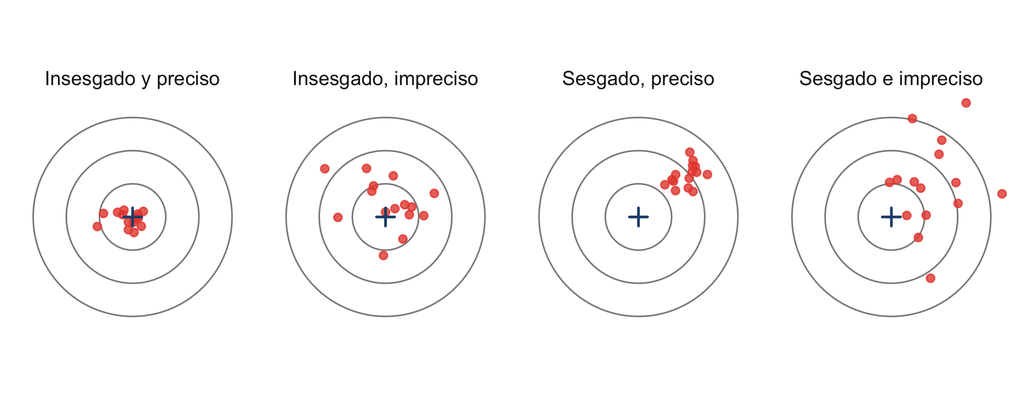

El centro de la diana es $\theta$; cada punto, una estimación con una muestra distinta. **Sesgo** = el centro de la nube no coincide con $\theta$; **varianza** = dispersión de la nube. El ECM penaliza ambos: $\operatorname{ECM} = \operatorname{Var} + \operatorname{Sesgo}^2$.

## Intervalo de confianza: derivación (1/2)

**Punto de partida.** Por el TCL (o exactamente, si $X_i \sim \mathcal{N}$), con $\sigma$ conocida:

$$Z = \frac{\bar{X}_n - \mu}{\sigma/\sqrt{n}} \sim \mathcal{N}(0, 1)$$

$Z$ es una cantidad **pivotal**: contiene a $\mu$, pero su distribución no depende de ningún parámetro desconocido. De la normal estándar sabemos que $z_{0.975} = 1.96$, luego:

$$P\left(-1.96 \le Z \le 1.96\right) = \Phi(1.96) - \Phi(-1.96) = 0.975 - 0.025 = 0.95$$

**Que significa esto:** antes de observar los datos, hay un 95% de probabilidad de que la media muestral caiga a menos de $1.96$ errores estándar de $\mu$. La derivación siguiente solo *despeja* $\mu$ de esa desigualdad.

## Intervalo de confianza: derivación (2/2)

Partimos de la probabilidad anterior y despejamos $\mu$ paso a paso:

$$\begin{aligned}
0.95 &= P\left(-1.96 \le \frac{\bar{X}_n - \mu}{\sigma/\sqrt{n}} \le 1.96\right) \\
&= P\left(-1.96\,\frac{\sigma}{\sqrt{n}} \le \bar{X}_n - \mu \le 1.96\,\frac{\sigma}{\sqrt{n}}\right) && \text{(multiplicar por } \sigma/\sqrt{n} > 0\text{)} \\
&= P\left(-\bar{X}_n - 1.96\,\frac{\sigma}{\sqrt{n}} \le -\mu \le -\bar{X}_n + 1.96\,\frac{\sigma}{\sqrt{n}}\right) && \text{(restar } \bar{X}_n\text{)} \\
&= P\left(\bar{X}_n - 1.96\,\frac{\sigma}{\sqrt{n}} \le \mu \le \bar{X}_n + 1.96\,\frac{\sigma}{\sqrt{n}}\right) && \text{(multiplicar por } -1 \text{ invierte)}
\end{aligned}$$

$$\boxed{\;IC_{95\%}(\mu) = \left[\bar{X}_n - 1.96\,\frac{\sigma}{\sqrt{n}},\;\; \bar{X}_n + 1.96\,\frac{\sigma}{\sqrt{n}}\right]\;}$$

Lo aleatorio son los **extremos**, no $\mu$: bajo muestreo repetido, el 95% de estos intervalos contiene a $\mu$.

## $\sigma$ desconocida: la t de Student

En la práctica $\sigma$ se estima con $s$, y ese reemplazo agrega incertidumbre. Si $X_i \sim \mathcal{N}(\mu, \sigma^2)$:

$$T = \frac{\bar{X}_n - \mu}{s/\sqrt{n}} \sim t_{n-1}$$

con $n - 1$ **grados de libertad**. La $t$ tiene colas más pesadas que la normal y converge a ella cuando $n \to \infty$.

$$IC_{95\%}(\mu) = \bar{X}_n \pm t_{n-1,\,0.975}\,\frac{s}{\sqrt{n}}$$

Con $n = 25$: $t_{24, 0.975} = 2.064 > 1.96$ — intervalos más anchos, el precio honesto de no conocer $\sigma$.

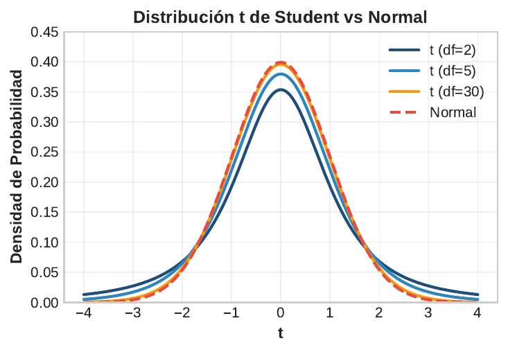

## Ejemplo IC paso a paso: ingreso de hogares beneficiarios

**Pregunta:** una muestra i.i.d. de $n = 36$ hogares beneficiarios de una transferencia reporta ingreso mensual con $\bar{x} = 520$ y $s = 90$ (miles de CLP). Construya el IC del 95% para el ingreso medio poblacional $\mu$.

**Paso 1 — Error estándar:**
$$\widehat{\operatorname{SE}} = \frac{s}{\sqrt{n}} = \frac{90}{\sqrt{36}} = \frac{90}{6} = 15$$

**Paso 2 — Valor crítico** ($gl = n - 1 = 35$): $t_{35,\,0.975} = 2.0301$ (en R: `qt(0.975, 35)`).

**Paso 3 — Margen de error:**
$$ME = t_{35,\,0.975} \times \widehat{\operatorname{SE}} = 2.0301 \times 15 = 30.45$$

**Paso 4 — Límites:**
$$IC_{95\%} = \left[520 - 30.45,\; 520 + 30.45\right] \;\Rightarrow\; \boxed{[489.55,\; 550.45]}$$

## Verificación con `t.test()` en R

```r
set.seed(123)
ingresos <- as.numeric(scale(rnorm(36))) * 90 + 520   # muestra con xbar = 520, s = 90 exactos
c(media = mean(ingresos), de = sd(ingresos), se = sd(ingresos) / sqrt(36))
```

```
media    de    se
  520    90    15
```

```r
tidy(t.test(ingresos)) %>%
  select(estimate, conf.low, conf.high) %>% kable(digits = 2)
```

| estimate | conf.low | conf.high |
| --- | --- | --- |
| 520 | 489.55 | 550.45 |

Los límites de `t.test()` — $[489.55,\ 550.45]$ — coinciden exactamente con el cálculo manual. Con 95% de confianza, el ingreso medio de la población beneficiaria está entre **489.6 y 550.4 mil CLP**: si la línea de elegibilidad del programa fuera 560, este dato descartaría (al 95%) que el hogar promedio la supere.

## Interpretación del IC: una correcta, muchas incorrectas

| Afirmación sobre $IC_{95\%} = [489.55,\ 550.45]$ | ¿Válida? |
| --- | --- |
| El procedimiento que generó este intervalo captura a $\mu$ el 95% de las veces bajo muestreo repetido | **Sí** |
| Hay 95% de probabilidad de que $\mu$ esté entre 489.55 y 550.45 | No: $\mu$ es fijo; el intervalo ya lo contiene o no |
| El 95% de los hogares tiene ingreso en ese rango | No: el IC es para la **media**, no para individuos |
| El 95% de las medias muestrales futuras caerá en ese rango | No: confunde IC con distribución de $\bar{X}$ |
| Con otra muestra obtendríamos el mismo intervalo | No: los extremos son aleatorios |

La confianza es una propiedad del **procedimiento**, no de un intervalo particular. La frase operativa honesta: “con 95% de confianza, $\mu$ está entre 489.6 y 550.4”.

## Simulación de cobertura: 100 intervalos, $\mu = 50$

```r
set.seed(1)
ics <- map_dfr(1:100, function(i) {
  x <- rnorm(30, mean = 50, sd = 10)
  ci <- t.test(x)$conf.int
  tibble(id = i, li = ci[1],
         ls = ci[2])
})
ics <- ics %>%
  mutate(cubre = li <= 50 & ls >= 50)
sum(ics$cubre)   # 95 de 100
```

Cada segmento es el IC de una muestra distinta de la **misma** población. En esta corrida, **95 de 100** contienen a $\mu = 50$ — la tasa nominal en acción.

[interactive chart not shown]

## El ancho del intervalo: qué lo gobierna

$$\text{ancho} = 2\; t_{n-1,\,1-\alpha/2}\;\frac{s}{\sqrt{n}}$$

Con los datos del ejemplo ($s = 90$):

- $n = 36$, 95%: ancho $= 2(2.030)(15) = 60.9$
- $n = 36$, **99%**: ancho $= 2(2.724)(15) = 81.7$ — más confianza, menos precisión
- $n = 144$, 95%: ancho $= 2(1.977)(7.5) = 29.7$ — cuadruplicar $n$ **divide el ancho por 2**

**Que significa esto:** precisión y confianza se compran con tamaño muestral, y el precio crece cuadráticamente.

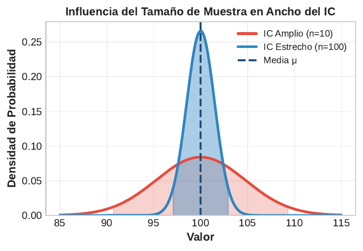

## Contraste de hipótesis: procedimiento formal en 6 pasos

1. **Hipótesis:** $H_0: \theta = \theta_0$ (statu quo) vs $H_1: \theta \ne \theta_0$ (bilateral) o $>, <$ (unilateral). Se plantean **antes** de mirar los datos.
2. **Estadístico de contraste:** una función de la muestra con distribución conocida bajo $H_0$; para la media con $\sigma$ desconocida, $T = \dfrac{\bar{X}_n - \theta_0}{s/\sqrt{n}}$.
3. **Distribución nula:** $T \sim t_{n-1}$ si $H_0$ es cierta (exacta bajo normalidad, aproximada por TCL).
4. **Regla de decisión:** fijar $\alpha$ (típicamente 0.05) y rechazar $H_0$ si $|t| > t_{n-1,\,1-\alpha/2}$, o equivalentemente si valor-p $< \alpha$.
5. **Cálculo:** evaluar $t$ con los datos y obtener el valor-p.
6. **Conclusión en contexto:** traducir “rechazo / no rechazo” a la pregunta de política, con magnitud y dirección.

El contraste es una **prueba por contradicción probabilística**: suponemos $H_0$ cierta y medimos cuán inverosímil resulta lo observado bajo ese supuesto.

## Ejemplo completo (1/2): ¿difiere el puntaje de la meta nacional?

**Pregunta empírica:** la meta nacional de una prueba estandarizada es $256$ puntos. En una muestra i.i.d. de $n = 25$ escuelas de un municipio, $\bar{x} = 268$ y $s = 24$. Con $\alpha = 0.05$, ¿el puntaje medio municipal **difiere** de la meta?

**Paso 1 — Hipótesis:**
$$H_0: \mu = 256 \qquad \text{vs} \qquad H_1: \mu \ne 256$$

**Paso 2 — Estadístico de contraste:**
$$T = \frac{\bar{X}_n - 256}{s/\sqrt{n}}$$

**Paso 3 — Distribución nula:** bajo $H_0$, $T \sim t_{24}$.

**Paso 4 — Regla de decisión:** con $\alpha = 0.05$ bilateral, rechazar $H_0$ si $|t| > t_{24,\,0.975} = 2.064$.

## Ejemplo completo (2/2): cálculo, decisión y verificación

**Paso 5 — Cálculo explícito:**
$$\widehat{\operatorname{SE}} = \frac{24}{\sqrt{25}} = \frac{24}{5} = 4.8 \qquad t = \frac{268 - 256}{4.8} = \frac{12}{4.8} = 2.50$$
$$\text{valor-p} = 2\,P(T_{24} \ge 2.50) = 0.0197$$

**Paso 6 — Conclusión:** como $|2.50| > 2.064$ (y $0.0197 < 0.05$), $\boxed{\text{se rechaza } H_0 \text{ al } 5\%}$: el puntaje medio municipal difiere de la meta — está **12 puntos por encima** ($IC_{95\%} = [258.1,\ 277.9]$, que excluye 256).

```r
set.seed(42)
puntajes <- as.numeric(scale(rnorm(25))) * 24 + 268   # xbar = 268, s = 24 exactos
tidy(t.test(puntajes, mu = 256)) %>%
  select(estimate, statistic, p.value, conf.low, conf.high) %>% kable(digits = 4)
```

| estimate | statistic | p.value | conf.low | conf.high |
| --- | --- | --- | --- | --- |
| 268 | 2.5 | 0.0197 | 258.0933 | 277.9067 |

`t.test()` reproduce el cálculo manual: $t = 2.5$, valor-p $= 0.0197$.

## Errores tipo I y tipo II: definiciones formales

$$\alpha = P\left(\text{rechazar } H_0 \mid H_0 \text{ cierta}\right)$$
$$\beta = P\left(\text{no rechazar } H_0 \mid H_1 \text{ cierta}\right)$$

- **Tipo I (falso positivo):** declarar que el programa tiene efecto cuando no lo tiene — se gasta en escalar una política inútil.
- **Tipo II (falso negativo):** no detectar un efecto real — se cancela una política que funcionaba.
- $\alpha$ lo fija el investigador **antes** del análisis; $\beta$ depende de $n$, del tamaño del efecto y de $\sigma$.
- Con $n$ fijo, bajar $\alpha$ **sube** $\beta$: no hay almuerzo gratis.

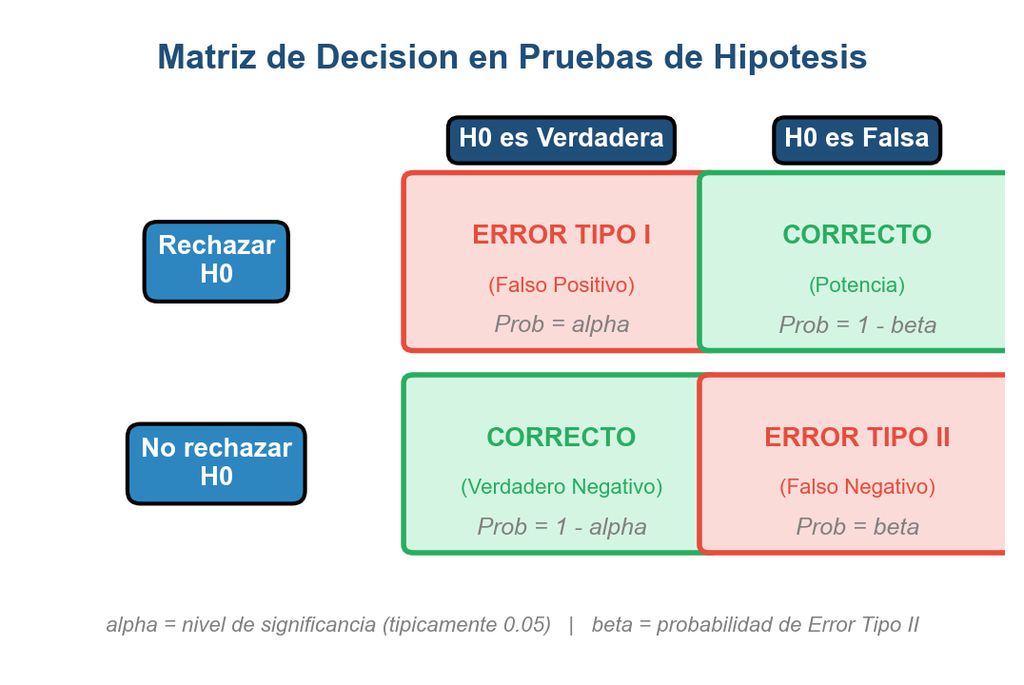

## $\alpha$, $\beta$ y potencia en un solo gráfico

[interactive chart not shown]

Con el efecto verdadero a $2.5$ errores estándar y regla bilateral con corte en $1.96$: $\beta = P(-1.96 \le Z_{H_1} \le 1.96) = 0.295$ y potencia $1 - \beta = 0.705$. Mover el corte a la derecha (bajar $\alpha$) agranda el área naranja: menos falsos positivos, más falsos negativos.

## Valor-p: definición formal

$$\text{valor-p} = P\left(\,|T| \ge |t_{obs}|\;\middle|\;H_0 \text{ cierta}\right)$$

La probabilidad — **calculada suponiendo $H_0$ cierta** — de observar un estadístico tan o más extremo que el obtenido.

En el ejemplo: $t_{obs} = 2.50$ con $T \sim t_{24}$,

$$\text{valor-p} = 2\,P(T_{24} \ge 2.50) = 0.0197$$

Es una medida de **incompatibilidad entre los datos y $H_0$**: mientras más pequeño, más raro sería lo observado si $H_0$ fuera cierta.

[interactive chart not shown]

## Valor-p: lo que NO significa

| Malinterpretación frecuente | Por qué es falsa |
| --- | --- |
| “p es la probabilidad de que $H_0$ sea cierta” | El valor-p se calcula **asumiendo** $H_0$ cierta; no es $P(H_0 \mid \text{datos})$ |
| “p $< 0.05$ prueba que el efecto existe” | Solo indica incompatibilidad con $H_0$; puede ser un error tipo I |
| “p $> 0.05$ demuestra que no hay efecto” | Ausencia de evidencia no es evidencia de ausencia (quizás faltó potencia) |
| “p mide el tamaño del efecto” | Con $n$ enorme, efectos triviales dan p minúsculos; reporte el IC |
| “p es la probabilidad de equivocarse al rechazar” | Esa tasa es $\alpha$, fijada de antemano, no el p observado |

Buenas prácticas (ASA, 2016): reportar siempre la **estimación puntual con su IC**, el valor-p exacto (no solo “p $< 0.05$”) y el tamaño muestral. La significancia estadística no es significancia práctica ni relevancia de política.

## Potencia estadística: $1 - \beta$

$$1 - \beta = P\left(\text{rechazar } H_0 \mid H_1 \text{ cierta}\right)$$

La probabilidad de **detectar un efecto que sí existe**. Convención de diseño: potencia $\ge 0.80$.

**Cuatro palancas la determinan:**

- $n \uparrow \;\Rightarrow\;$ potencia $\uparrow$ (SE cae con $\sqrt{n}$)
- Tamaño del efecto $|\mu_1 - \mu_0| \uparrow \;\Rightarrow\;$ potencia $\uparrow$
- $\alpha \uparrow \;\Rightarrow\;$ potencia $\uparrow$ (a costa de más falsos positivos)
- $\sigma \downarrow \;\Rightarrow\;$ potencia $\uparrow$ (medir mejor, poblaciones homogéneas)

**Que significa esto:** una evaluación con potencia 0.36 tiene un 64% de probabilidad de “no encontrar” un efecto real — el estudio nace condenado.

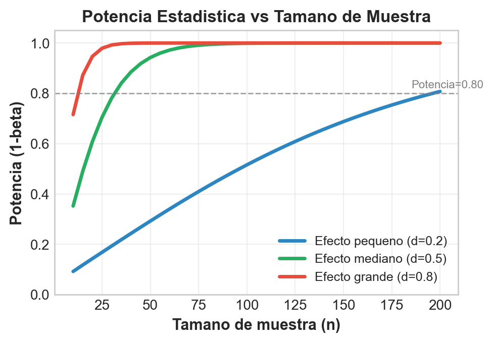

## Curva de potencia con `power.t.test()`

```r
d <- seq(2, 20, by = 0.5)
pot <- map_dbl(d, function(delta)
  power.t.test(n = 25, delta = delta,
    sd = 24, sig.level = 0.05,
    type = "one.sample")$power)
```

Con los datos del ejemplo ($s = 24$):

- Detectar $\delta = 8$ puntos con $n = 25$: potencia $= 0.36$ — insuficiente.
- Para potencia $0.80$ con $\delta = 8$ se requiere $n = 73$.
- Con $n = 25$ solo efectos $\delta \ge 12$ superan potencia $0.67$.

[interactive chart not shown]

## El flujo inferencial completo

| Paso | Pregunta | Herramienta formal | En R |
| --- | --- | --- | --- |
| 1. Estimar | ¿Cuál es el valor de $\theta$? | $\bar{X}_n$, $s^2$, $\hat{p}$ | `mean()`, `var()` |
| 2. Precisión | ¿Cuánto varía el estimador? | $\operatorname{SE} = s/\sqrt{n}$ | `sd(x)/sqrt(n)` |
| 3. Rango plausible | ¿Dónde está $\mu$? | $\bar{X}_n \pm t_{n-1}\,\operatorname{SE}$ | `t.test(x)` |
| 4. Decisión | ¿Es compatible con $\theta_0$? | 6 pasos, $t$, valor-p | `t.test(x, mu = )` |
| 5. Riesgos | ¿Qué errores puedo cometer? | $\alpha$, $\beta$, matriz de decisión | fijar $\alpha$ ex ante |
| 6. Diseño | ¿Qué $n$ necesito? | potencia $1 - \beta \ge 0.80$ | `power.t.test()` |

**Hilo conductor:** todo descansa en la distribución muestral ($\mathbb{E}[\bar{X}] = \mu$, $\operatorname{Var}(\bar{X}) = \sigma^2/n$) y en el TCL, que garantiza la forma normal aproximada. **Próximo bloque:** correlación y regresión lineal simple — la inferencia aplicada a la relación entre dos variables.

## Ejercicios propuestos (con respuestas)

Una encuesta de satisfacción con un servicio público entrevista a $n = 49$ usuarios: $\bar{x} = 72$ y $s = 14$ (escala 0–100).

1. Calcule el error estándar y el IC del 95% para la satisfacción media $\mu$.
2. La meta institucional es $\mu_0 = 75$. Contraste $H_0: \mu = 75$ vs $H_1: \mu \ne 75$ con $\alpha = 0.05$ siguiendo los 6 pasos.
3. ¿Qué potencia tiene este diseño para detectar una desviación real de 3 puntos? ¿Qué $n$ exigiría potencia 0.90? Use `power.t.test(delta = 3, sd = 14, type = "one.sample")`.
4. Explique por qué “no rechazar $H_0$” en (2) no demuestra que la meta se cumple.

**Respuestas:** (1) $\operatorname{SE} = 14/7 = 2$; $t_{48,0.975} = 2.011$; $IC_{95\%} = [67.98,\ 76.02]$. (2) $t = (72 - 75)/2 = -1.5$; valor-p $= 0.140 > 0.05$: no se rechaza $H_0$ — los datos son compatibles con la meta. (3) Potencia $= 0.31$; para $0.90$ se requiere $n = 231$. (4) Con potencia 0.31, la probabilidad de no detectar una desviación real de 3 puntos es 69%: el resultado es no concluyente, no una confirmación. **Referencias:** Wasserman, *All of Statistics* (caps. 6–10) · Illowsky & Dean, *Introductory Statistics* (caps. 7–9) · Wasserstein & Lazar (2016), *The ASA Statement on p-Values*.